# Detecting Phishing URLs from Structural and Content-Based Web Features

## 7.2 ROC Curves and AUC

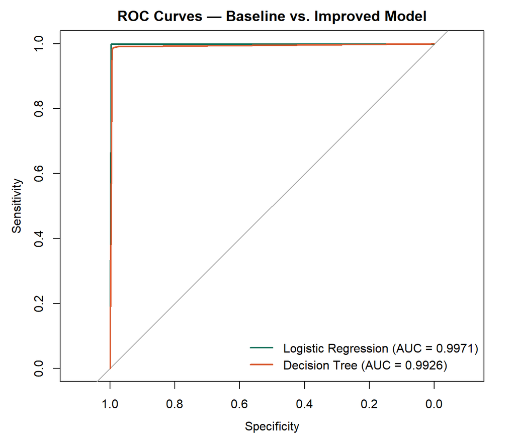

```r
roc_logit <- roc(response = test_data$label, predictor = logit_probs,
                  levels = c("Phishing", "Legitimate"), quiet = TRUE)
roc_tree  <- roc(response = test_data$label, predictor = tree_probs,
                  levels = c("Phishing", "Legitimate"), quiet = TRUE)

plot(roc_logit, col = "#0F6E56", lwd = 2,
     main = "ROC Curves — Baseline vs. Improved Model")
plot(roc_tree, col = "#D85A30", lwd = 2, add = TRUE)
legend("bottomright",
       legend = c(paste0("Logistic Regression (AUC = ", round(auc(roc_logit), 4), ")"),
                  paste0("Decision Tree (AUC = ", round(auc(roc_tree), 4), ")")),
       col = c("#0F6E56", "#D85A30"), lwd = 2, bty = "n")
```

**Observation:** Both ROC curves are expected to hug the top-left corner very closely, with AUC values close to 1.0 for both models — logistic regression typically edges out the single decision tree very slightly on this dataset, since a linear combination of many individually-informative standardised features can separate the classes almost as cleanly as a set of hard splitting rules, without the tree’s risk of overfitting to a few specific thresholds.